# Hayman Fire Recovery

Casey Menick

01/31/2022

# Background

The Hayman Fire occurred in the summer of 2002, and at the time, was the largest wildfire in Colorado History. It burned nearly 140,000 acres, and caused extreme environmental and monetary damage. There were extensive areas of high-severity burning that will have long-standing impacts on the area.

This project aims to investigate some relationships between NDMI, NDSI, and NDVI in the area around the fire. Data were taken from ClimateEngine from two areas (one burned, one unburned) from 1984-2019 to look at these trends over time.

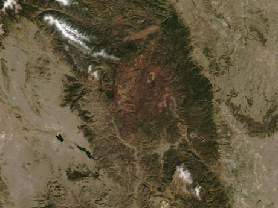

# Data Setup

## Library Import

```r
library(tidyverse)
library(tidyr)
library(ggthemes)
library(lubridate)

# Now that we have learned how to munge (manipulate) data
# and plot it, we will work on using these skills in new ways

knitr::opts_knit$set(root.dir='..')
```

## Import Data into Tidy Dataset

```r
####-----Reading in Data and Stacking it ----- ####
#Reading in files
setwd('G:/Other computers/Lenovo/Documents/Grad School/Classes/Spring 2022/ES580A7/2_fire_data_wrangle/data')

#Read in individual data files
ndmi <- read.csv('hayman_ndmi.csv') %>%
  rename(burned=2,unburned=3) %>%
  mutate(data='ndmi')


ndsi <- read.csv('hayman_ndsi.csv') %>%
  rename(burned=2,unburned=3) %>%
  mutate(data='ndsi')

ndvi <- read.csv('hayman_ndvi.csv')%>%
  rename(burned=2,unburned=3) %>%
  mutate(data='ndvi')

# Stack as a tidy dataset
full_long <- rbind(ndvi,ndmi,ndsi)%>%
  pivot_longer(.,cols=c('burned','unburned'),names_to="site") %>%
  #updated from gather(key='site',value='value',-DateTime,-data) %>%
  filter(!is.na(value))
```

# Questions of Interest

## Question 1

**What is the correlation between NDVI and NDMI in the burned and unburned areas?**

*Both sites displayed a positive relationship between NDMI and NDVI over the course of May-September, implying that wetness is correlated with greenness. The burned site had a much wider spread of NDMI and NDVI values, which makes sense given the change to vegetation in that area*

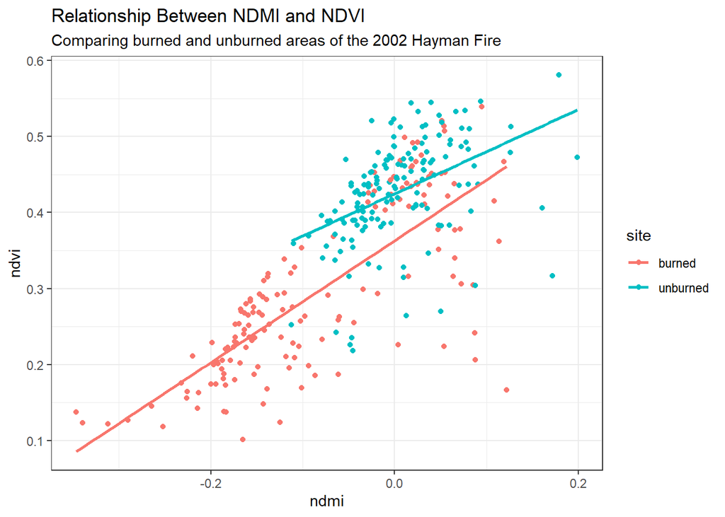

```r
#change dataset from long to wide
full_wide <-full_long %>%
  pivot_wider(.,id_cols=c('DateTime','site','value'),names_from = data) %>%  # updated from spread(key="data",value="value")
  filter(!is.na(ndvi)) %>% #remove NAs from each column
  filter(!is.na(ndsi)) %>%
  filter(!is.na(ndmi)) %>%
  mutate(month=month(DateTime), #convert date to month and year
         year=year(DateTime),
         burnstatus=if_else(year %in% c(1984:2002),"Before 2002 Burn","Post 2002 Burn"))

#Plot NDMI and NDVI
ggplot(full_wide%>%filter(month==c(5,6,7,8,9)),aes(ndmi,ndvi,color=site)) +
  geom_point()+
  geom_smooth(method="lm",se=FALSE) +
  theme_bw() +
  labs(title="Relationship Between NDMI and NDVI", subtitle="Comparing burned and unburned areas of the 2002 Hayman Fire")
```

## Question 2

**What is the correlation between average NDSI for January - April and average NDVI for June-August in this area?**

*There was not much of a relationship between winter NDSI (January-April) and summer NDVI (June-August) for both burned and unburned sites. This gives evidence to support that the previous year’s snow cover does not have much influence on vegetation growth for the following summer. This implies that their are likely other climatic or environmental variables that are more influential on seasonal vegetation growth. Both sites showed similar values for NDSI, and the unburned area unsurprisingly having a much higher NDVI.*

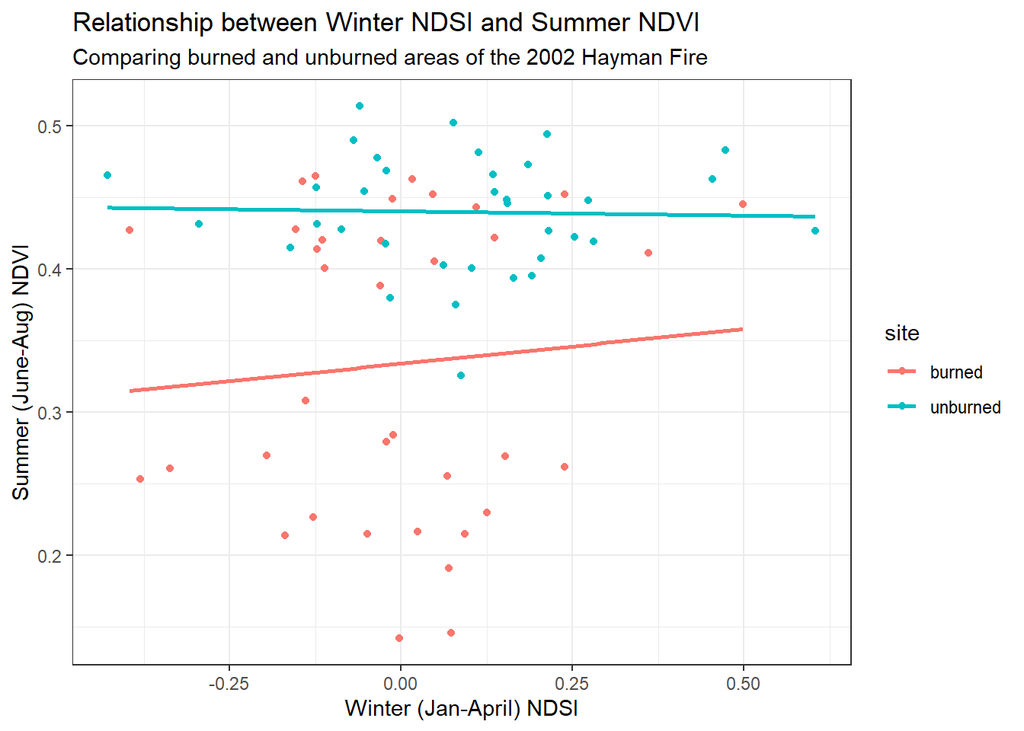

```r
#Convert data to add in season field, and pivot wider to have one year row with summer ndvi and winter ndsi columns
full_long_season <- full_long %>%
  mutate(month=month(DateTime), #add in month and year from the date field
         year=year(DateTime)) %>%
  filter(month %in% c(1,2,3,4,6,7,8), #filter to only summer and winter months of interest, for only ndvi and ndsi
         data %in% c('ndvi','ndsi')) %>%
  mutate(season=if_else(month %in% c(1,2,3,4),"winter","summer")) %>% #create new field for summer and winter, comprised of all months of interest
  group_by(season,year,site,data) %>% #group by season, year, burn status, and field type; summarize
  summarize(value=mean(value)) %>%
  filter(data=="ndvi" & season=="summer" | data=="ndsi" & season=="winter") %>% #select only for summer ndvi and winter ndsi
  .[c(1,2,3,5)] %>% #remove data field
  pivot_wider(.,id_cols=c('year', 'site', 'value'),names_from='season') #back to wide, summer/winter values each a column for each year; updated from  spread(key="season",value="value")

#Plot Winter NDSI and Summer NDVI
ggplot(full_long_season,aes(winter,summer,color=site)) +
  geom_point() +
  geom_smooth(method="lm",se=FALSE) +
  xlab("Winter (Jan-April) NDSI") + ylab("Summer (June-Aug) NDVI") +
  labs(title="Relationship between Winter NDSI and Summer NDVI",subtitle="Comparing burned and unburned areas of the 2002 Hayman Fire")+
  theme_bw()
```

## Question 3

**Does the relationship between NDSI and NDVI differ in the burned and unburned areas?**

*Winter NDSI still does not have much relationship to summer NDSI for either time point. Before the 2002 burn, both sites had fairly similar NDVI and NDSI relationships, with the burned area having slightly lower NDVI overall. After 2002, the burned area has much lower NDVI, as would be expected.*

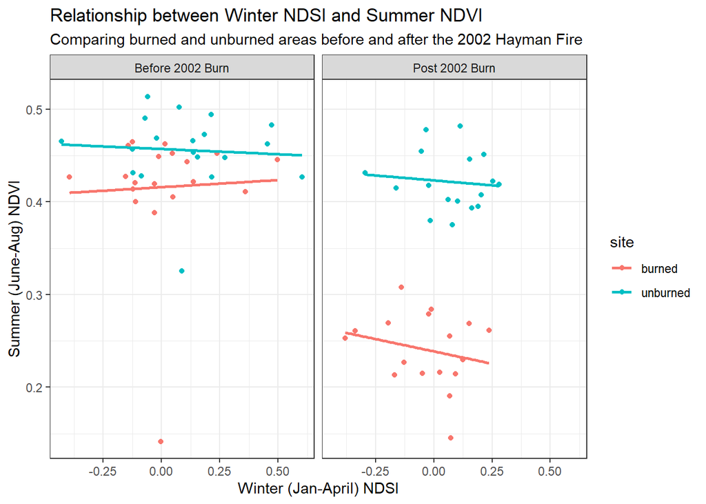

```r
#add column 'burnstatus' to reflect pre or post 2002 fire
full_long_season_status <- full_long_season %>%
  mutate(burnstatus=if_else(year %in% c(1984:2002),"Before 2002 Burn","Post 2002 Burn"))

#Plot Winter NDSI and Summer NDVI, compring burned and unburned areas, faceted by time
ggplot(full_long_season_status,aes(winter,summer,color=site)) +
  geom_point() +
  geom_smooth(method="lm",se=FALSE) +
  facet_wrap(~burnstatus) +
  xlab("Winter (Jan-April) NDSI") + ylab("Summer (June-Aug) NDVI") + labs(title="Relationship between Winter NDSI and Summer NDVI",subtitle="Comparing burned and unburned areas before and after the 2002 Hayman Fire") +
  theme_bw()
```

## Question 4

**What month is the greenest month on average for the burned and unburned areas?**

*The greenest month on average is August for the burned area and September for the unburned area. The burned area likely has an earlier peak of vegetation, relying on winter snow melt for moisture and more impacted by later season high temperatures or drought*

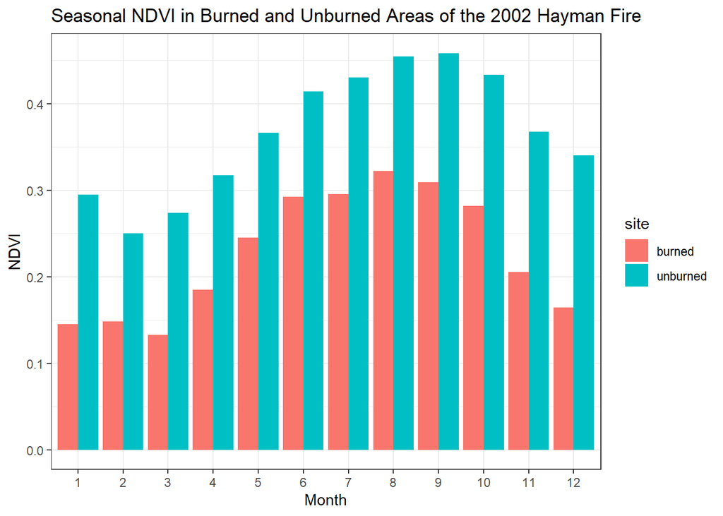

```r
#Filter long data to contain just ndvi, arranged by month
full_long_month <- full_long %>%
  mutate(month=month(DateTime),
         year=year(DateTime)) %>%
  filter(data=='ndvi') %>%
  group_by(month,site) %>%
  summarize(value=mean(value))

#Plot NDVI over time
ggplot(full_long_month,aes(as.factor(month),value,fill=site)) +
  geom_col(position="dodge") + xlab("Month") + ylab("NDVI")+ labs(title="Seasonal NDVI in Burned and Unburned Areas of the 2002 Hayman Fire")+
  theme_bw()
```

## Question 5

**What month is the snowiest month on average for the burned and unburned areas?**

*The snowiest month is January for the burned site and February for the unburned site. Overall, the burned site had lower snow cover that arrived later and disappated sooner than the unburned area, likely to due lack of vegetation in the area*

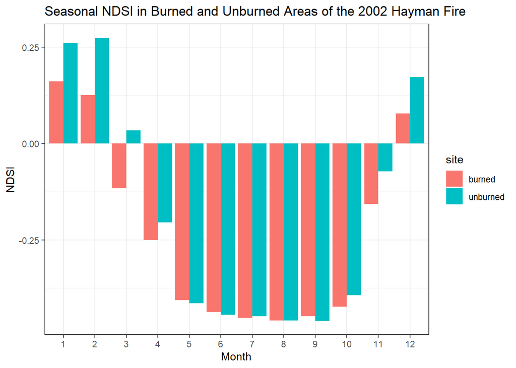

```r
#Filter long data to just contain NDSI, arranged by month
full_long_month2 <- full_long %>%
  mutate(month=month(DateTime),
         year=year(DateTime)) %>%
  filter(data=='ndsi') %>%
  group_by(month,site) %>%
  summarize(value=mean(value))

#Plot NDSI over time
ggplot(full_long_month2,aes(as.factor(month),value,fill=site)) +
  geom_col(position="dodge") + xlab("Month") + ylab("NDSI")+ theme_bw()+ labs(title="Seasonal NDSI in Burned and Unburned Areas of the 2002 Hayman Fire")
```

## Additional Questions

*Summer NDVI (May-Sept) is interesting to look at this area over time. Years of drought, marked by much lower NDVI values, are more prevalent in the burned area, indicating that this area was likely more at risk of fire. The fire itself expectedly significantly reduced NDVI in the burned area, but also influenced the nearby unburned area. Both areas have been increasing since 2002.*

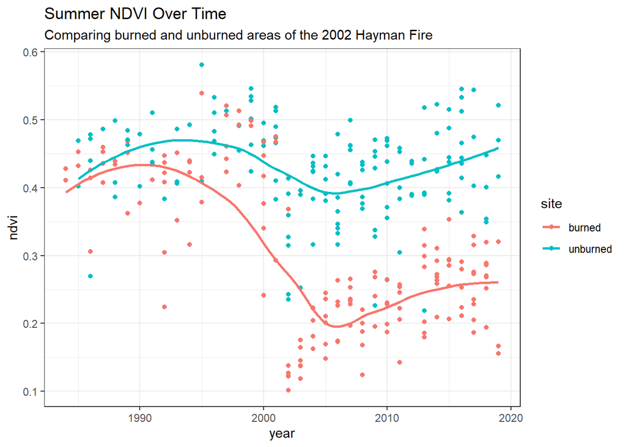

```r
#Plot NDVI Over Time
ggplot(full_wide%>%filter(month==c(5,6,7,8,9)),aes(year,ndvi,color=site)) +
  geom_point()+
  geom_smooth(se=FALSE) +
  theme_bw() +
  labs(title="Summer NDVI Over Time", subtitle="Comparing burned and unburned areas of the 2002 Hayman Fire")
```

## Bonus Questions

**Redo all problems with `spread` and `gather` using modern tidyverse syntax.**

**Use Climage Engine to pull the same data for the assignment, but updated with 2020/2021 data.**